# UTS

Rani Yasmin Azzahra

2023-10-06

## Library

```r
library(ggplot2)
library(tsibble)
library(tseries)
library(MASS)
library(forecast)
library(TSA)
library(TTR)
library(aTSA)
library(graphics)
```

## Input data

kolom data baru dengan penambahan data + nomor acak 727

```r
df <- rio::import("https://raw.githubusercontent.com/raniysmnz/MPDW/main/Data/datauts.csv")
str(df)
```

```
## 'data.frame':    151 obs. of  3 variables:
##  $ Periode: int  1 2 3 4 5 6 7 8 9 10 ...
##  $ Data   : int  3980 4039 3878 3809 3829 3798 3730 3705 3701 3782 ...
##  $ baru   : int  4707 4766 4605 4536 4556 4525 4457 4432 4428 4509 ...
```

## Pembagian data

```r
baru <- df$baru
train <- baru[1:120]
test <- baru[121:151]
str(train)
```

```
##  int [1:120] 4707 4766 4605 4536 4556 4525 4457 4432 4428 4509 ...
```

## Eksplorasi data

### Plot ACF

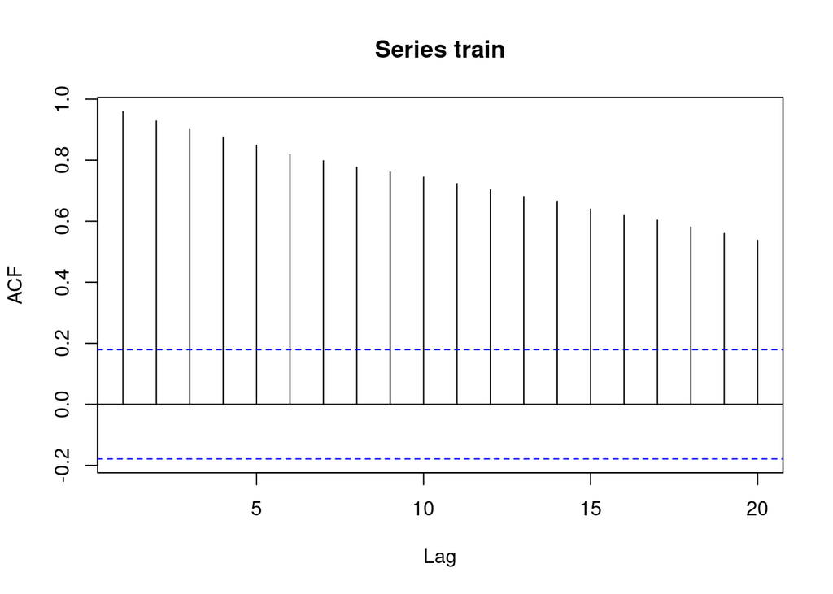

```r
train <- ts(train)
acf(train)
```

Plot cenderung menurun secara perlahan menandakan data tidak stasioner dalam rataan.

### Plot Time Series

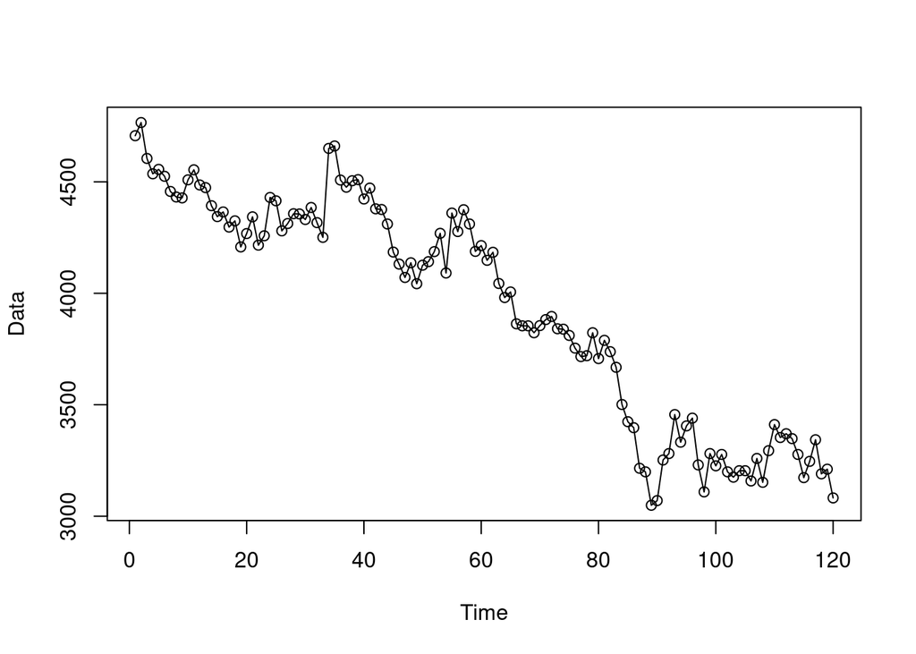

```r
plot(train,
     lwd = 1,
     type = "o",
     xlab = "Time",
     ylab = "Data")
```

```r
mean(train)
```

```
## [1] 3928.783
```

Berdasarkan eksplorasi dapat dilihat data cenderung tidak stasioner dalam rataan sebesar 3928.783

### Uji ADF (Kestasioneran dalam rataan)

```r
tseries::adf.test(train)
```

```
##
##  Augmented Dickey-Fuller Test
##
## data:  train
## Dickey-Fuller = -2.5599, Lag order = 4, p-value = 0.344
## alternative hypothesis: stationary
```

$H_0$ : Data tidak stasioner dalam rataan

$H_1$ : Data stasioner dalam rataan

Berdasarkan uji ADF tersebut, didapat *p-value* sebesar 0.344 yang lebih besar dari taraf nyata 5% sehingga menerima $H_0$ dan menandakan bahwa data tidak stasioner dalam rataan. Hal ini sesuai dengan hasil eksplorasi menggunakan plot time series dan plot ACF.

#### Plot Boxcox

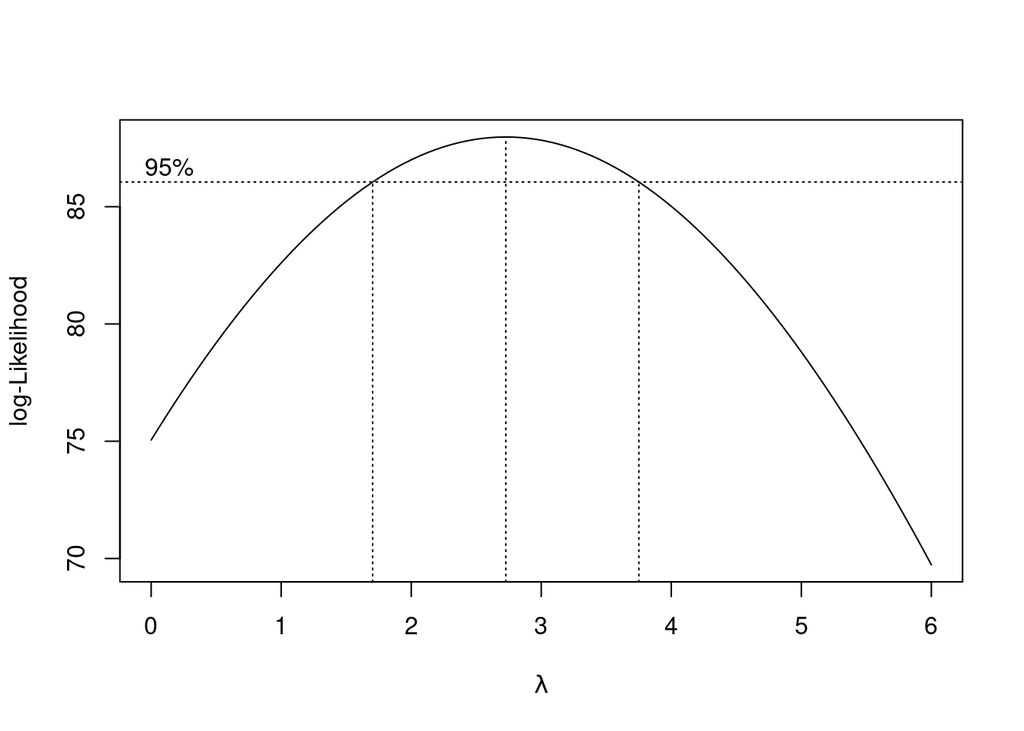

```r
index <- seq(1:120)
bc = MASS::boxcox(train~index, lambda = seq(0,6,by=1))
```

```r
#Nilai Rounded Lambda
lambda <- bc$x[which.max(bc$y)]
lambda
```

```
## [1] 2.727273
```

```r
#SK
bc$x[bc$y > max(bc$y) - 1/2 * qchisq(.95,1)]
```

```
##  [1] 1.757576 1.818182 1.878788 1.939394 2.000000 2.060606 2.121212 2.181818
##  [9] 2.242424 2.303030 2.363636 2.424242 2.484848 2.545455 2.606061 2.666667
## [17] 2.727273 2.787879 2.848485 2.909091 2.969697 3.030303 3.090909 3.151515
## [25] 3.212121 3.272727 3.333333 3.393939 3.454545 3.515152 3.575758 3.636364
## [33] 3.696970
```

Gambar di atas menunjukkan nilai *rounded value* ($\lambda$) optimum sebesar **2,72** dan pada selang kepercayaan 95% nilai memiliki batas bawah **1.757576** dan batas atas **3.696970**. Selang tersebut tidak memuat nilai satu sehingga dapat dikatakan bahwa data bangkitan tidak stasioner dalam ragam.

## Penanganan Ketidakstasioneran Data

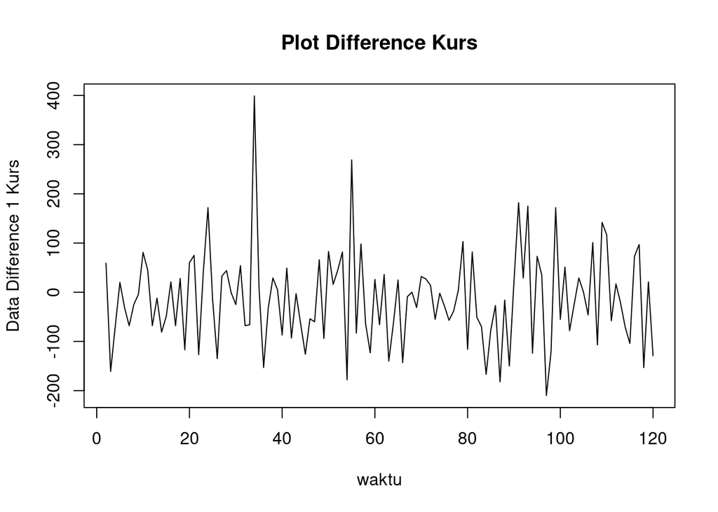

```r
train.diff<-diff(train,differences = 1)
plot.ts(train.diff, lty=1, xlab="waktu", ylab="Data Difference 1 Kurs", main="Plot Difference Kurs")
```

Berdasarkan plot data deret waktu, terlihat bahwa data sudah stasioner dalam rataan ditandai dengan data bergerak pada nilai tengah tertentu (tidak terdapat trend ataupun musiman pada data)

### Uji ADF (Kestasioneran dalam rataan)

```r
tseries::adf.test(train.diff)
```

```
##
##  Augmented Dickey-Fuller Test
##
## data:  train.diff
## Dickey-Fuller = -4.5242, Lag order = 4, p-value = 0.01
## alternative hypothesis: stationary
```

$H_0$ : Data tidak stasioner dalam rataan

$H_1$ : Data stasioner dalam rataan

Berdasarkan uji ADF tersebut, didapat *p-value* sebesar 0.01 yang lebih kecil dari taraf nyata 5% sehingga menolak $H_0$ dan menandakan bahwa data stasioner dalam rataan.

## Identifikasi Model Regresi Time Series

### Plot ACF

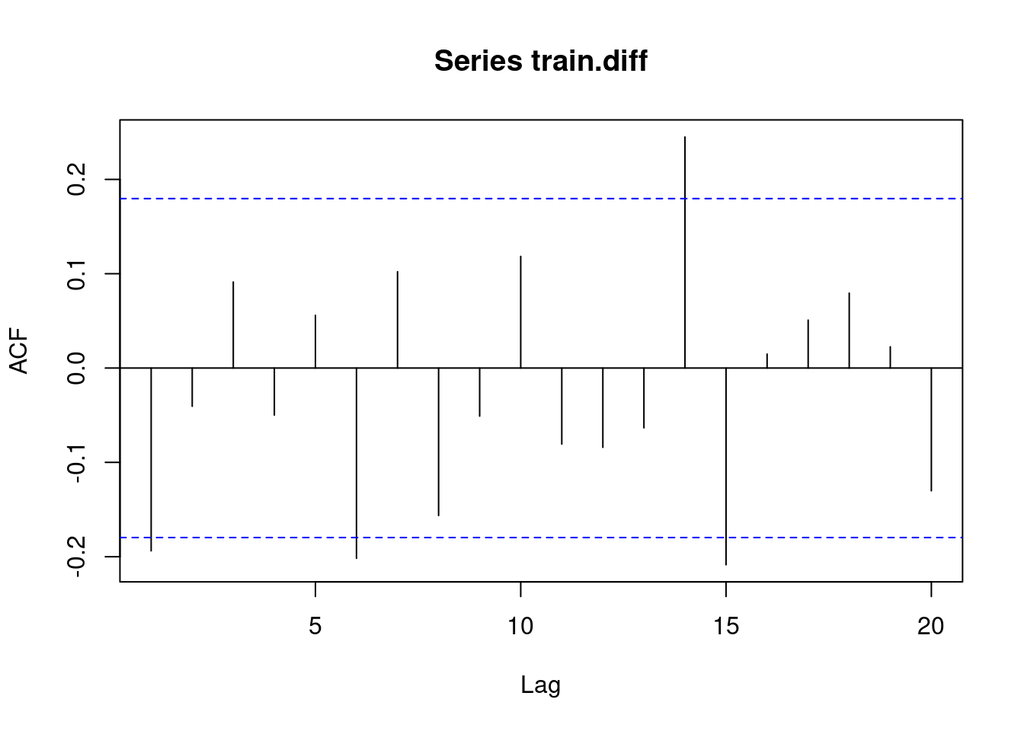

```r
acf(train.diff)
```

Plot ACF cenderung tails off

### Plot PACF

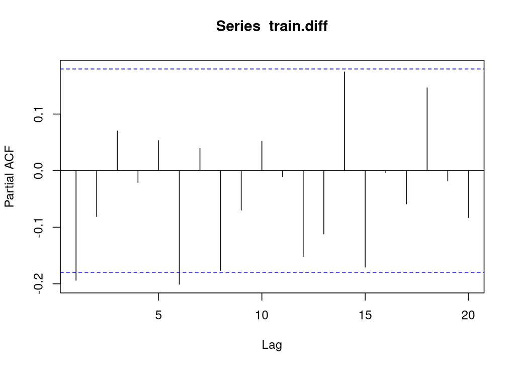

```r
pacf(train.diff)
```

Plot PACF cenderung tails off.

Kedua Plot ACF dan PACF cenderung tails off sehingga akan dicoba model ARIMA

### Plot EACF

```r
eacf(train.diff)
```

```
## AR/MA
##   0 1 2 3 4 5 6 7 8 9 10 11 12 13
## 0 x o o o o x o o o o o  o  o  x
## 1 x o o o o o o o o o o  o  o  o
## 2 x o o o o o o x o o o  o  o  o
## 3 x x o o o o o o o o o  o  o  o
## 4 x o o o o o o o o o o  o  o  o
## 5 x o x x x o o o o o o  o  o  o
## 6 o x x x x o o o o o o  o  o  o
## 7 x x x x o o x o o o o  o  o  o
```

Berdasarkan plot EACF akan dicoba model ARIMA(0,1,6), ARIMA(1,1,7), ARIMA(0,1,7)

## Pendugaan Parameter Model Tentatif

### ARIMA(0,1,6)

```r
model1=Arima(train.diff, order=c(0,1,6),method="ML")
summary(model1) #AIC=1421.44
```

```
## Series: train.diff
## ARIMA(0,1,6)
##
## Coefficients:
##           ma1     ma2     ma3      ma4     ma5      ma6
##       -1.1722  0.1181  0.2219  -0.2529  0.1228  -0.0376
## s.e.   0.0995  0.1451  0.1573   0.1571  0.1378   0.0904
##
## sigma^2 = 8939:  log likelihood = -703.72
## AIC=1421.44   AICc=1422.45   BIC=1440.83
##
## Training set error measures:
##                   ME     RMSE      MAE MPE MAPE      MASE         ACF1
## Training set 1.52407 91.72328 70.92542 Inf  Inf 0.6130383 -0.006995419
```

```r
lmtest::coeftest(model1) #hanya parameter MA1 yang signifikan
```

```
##
## z test of coefficients:
##
##      Estimate Std. Error  z value Pr(>|z|)
## ma1 -1.172220   0.099548 -11.7754   <2e-16 ***
## ma2  0.118109   0.145102   0.8140   0.4157
## ma3  0.221855   0.157338   1.4101   0.1585
## ma4 -0.252921   0.157138  -1.6095   0.1075
## ma5  0.122760   0.137772   0.8910   0.3729
## ma6 -0.037575   0.090363  -0.4158   0.6775
## ---
## Signif. codes:  0 '***' 0.001 '**' 0.01 '*' 0.05 '.' 0.1 ' ' 1
```

### ARIMA(1,1,7)

```r
model2=Arima(train.diff, order=c(1,1,7),method="ML")
summary(model2) #AIC=1420.82
```

```
## Series: train.diff
## ARIMA(1,1,7)
##
## Coefficients:
##           ar1      ma1      ma2     ma3      ma4      ma5      ma6     ma7
##       -0.1202  -1.0747  -0.0197  0.1610  -0.0617  -0.0024  -0.2330  0.2305
## s.e.   0.4304   0.4304   0.4851  0.1343   0.1806   0.1315   0.1355  0.1043
##
## sigma^2 = 8677:  log likelihood = -701.41
## AIC=1420.82   AICc=1422.48   BIC=1445.75
##
## Training set error measures:
##                     ME    RMSE      MAE MPE MAPE      MASE         ACF1
## Training set 0.6841735 89.5593 68.56556 Inf  Inf 0.5926411 -0.001273693
```

```r
lmtest::coeftest(model2) #hanya parameter MA1 dan MA7 yang signifikan
```

```
##
## z test of coefficients:
##
##       Estimate Std. Error z value Pr(>|z|)
## ar1 -0.1201559  0.4304176 -0.2792  0.78012
## ma1 -1.0747210  0.4303588 -2.4973  0.01252 *
## ma2 -0.0196954  0.4850815 -0.0406  0.96761
## ma3  0.1610111  0.1342593  1.1993  0.23043
## ma4 -0.0616826  0.1805943 -0.3416  0.73269
## ma5 -0.0024277  0.1315091 -0.0185  0.98527
## ma6 -0.2329549  0.1354515 -1.7198  0.08546 .
## ma7  0.2304967  0.1042529  2.2109  0.02704 *
## ---
## Signif. codes:  0 '***' 0.001 '**' 0.01 '*' 0.05 '.' 0.1 ' ' 1
```

### ARIMA(0,1,7)

```r
model3=Arima(train.diff, order=c(0,1,7),method="ML")
summary(model3) #AIC=1418.88
```

```
## Series: train.diff
## ARIMA(0,1,7)
##
## Coefficients:
##           ma1     ma2     ma3      ma4     ma5      ma6     ma7
##       -1.1929  0.1136  0.1634  -0.0951  0.0159  -0.2330  0.2282
## s.e.   0.0981  0.1385  0.1399   0.1653  0.1325   0.1365  0.1052
##
## sigma^2 = 8597:  log likelihood = -701.44
## AIC=1418.88   AICc=1420.2   BIC=1441.05
##
## Training set error measures:
##                     ME     RMSE      MAE MPE MAPE      MASE         ACF1
## Training set 0.5008592 89.54778 68.60365 Inf  Inf 0.5929703 -0.006061471
```

```r
lmtest::coeftest(model3) #hanya parameter MA1 dan MA7 yang signifikan
```

```
##
## z test of coefficients:
##
##      Estimate Std. Error  z value Pr(>|z|)
## ma1 -1.192877   0.098091 -12.1609  < 2e-16 ***
## ma2  0.113550   0.138520   0.8197  0.41236
## ma3  0.163423   0.139920   1.1680  0.24282
## ma4 -0.095139   0.165282  -0.5756  0.56488
## ma5  0.015913   0.132535   0.1201  0.90443
## ma6 -0.233025   0.136464  -1.7076  0.08771 .
## ma7  0.228164   0.105218   2.1685  0.03012 *
## ---
## Signif. codes:  0 '***' 0.001 '**' 0.01 '*' 0.05 '.' 0.1 ' ' 1
```

### ARIMA(3,1,3)

```r
model4=Arima(train.diff, order=c(3,1,3),method="ML")
summary(model4) #AIC=1420.47
```

```
## Series: train.diff
## ARIMA(3,1,3)
##
## Coefficients:
##           ar1     ar2     ar3      ma1      ma2     ma3
##       -0.5042  0.2112  0.1462  -0.6719  -0.6716  0.3436
## s.e.   0.7984  0.7529  0.1755   0.8061   0.2329  0.6497
##
## sigma^2 = 8859:  log likelihood = -703.23
## AIC=1420.47   AICc=1421.49   BIC=1439.86
##
## Training set error measures:
##                    ME     RMSE      MAE MPE MAPE      MASE       ACF1
## Training set 1.543462 91.31345 70.46525 Inf  Inf 0.6090609 0.00243906
```

```r
lmtest::coeftest(model4) #hanya parameter MA2 yang signifikan
```

```
##
## z test of coefficients:
##
##     Estimate Std. Error z value Pr(>|z|)
## ar1 -0.50421    0.79836 -0.6316 0.527673
## ar2  0.21119    0.75290  0.2805 0.779095
## ar3  0.14617    0.17549  0.8329 0.404874
## ma1 -0.67193    0.80614 -0.8335 0.404555
## ma2 -0.67164    0.23290 -2.8838 0.003929 **
## ma3  0.34358    0.64972  0.5288 0.596932
## ---
## Signif. codes:  0 '***' 0.001 '**' 0.01 '*' 0.05 '.' 0.1 ' ' 1
```

Berdasarkan pendugaan parameter di atas, nilai AIC terkecil dimiliki oleh model ARIMA(0,1,7) dan parameter model ARIMA(0,1,7) memiliki dua parameter signifikan sehingga model yang dipilih adalah model ARIMA(0,1,7).

## Analisis Sisaan

Model terbaik hasil identifikasi kemudian dicek asumsi sisaannya. Sisaan model ARIMA harus memenuhi asumsi normalitas, kebebasan sisaan, dan kehomogenan ragam. Diagnostik model dilakukan secara eksplorasi dan uji formal.

### Eksplorasi Sisaan

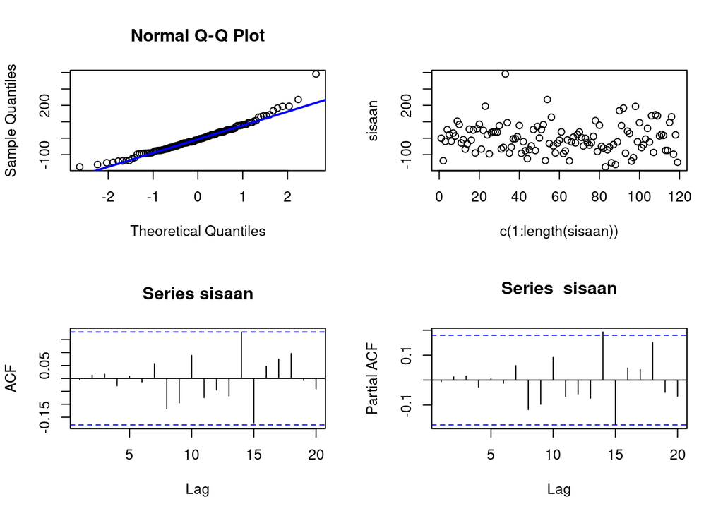

```r
#Eksplorasi
sisaan <- model3$residuals
par(mfrow=c(2,2))
qqnorm(sisaan)
qqline(sisaan, col = "blue", lwd = 2)
plot(c(1:length(sisaan)),sisaan)
acf(sisaan)
pacf(sisaan)
```

```r
par(mfrow = c(1,1))
```

## Uji Formal

```r
#1) Sisaan Menyebar Normal
ks.test(sisaan,"pnorm")  #tolak H0 > sisaan tidak menyebar normal
```

```
##
##  Asymptotic one-sample Kolmogorov-Smirnov test
##
## data:  sisaan
## D = 0.52735, p-value < 2.2e-16
## alternative hypothesis: two-sided
```

Selain dengan eksplorasi, asumsi tersebut dapat diuji menggunakan uji formal. Pada tahapan ini uji formal yang digunakan untuk normalitas adalah uji Kolmogorov-Smirnov (KS). Hipotesis pada uji KS adalah sebagai berikut.

$H_0$ : Sisaan menyebar normal

$H_1$ : Sisaan tidak menyebar normal

Berdasarkan uji KS tersebut, didapat *p-value* sebesar 0.00 yang kurang dari taraf nyata 5% sehingga tolak $H_0$ dan menandakan bahwa sisaan tidak menyebar normal. Hal ini berbeda dengan hasil eksplorasi menggunakan plot kuantil-kuantil normal.

```r
#2) Sisaan saling bebas/tidak ada autokorelasi
Box.test(sisaan, type = "Ljung")  #tak tolak H0 > sisaan saling bebas
```

```
##
##  Box-Ljung test
##
## data:  sisaan
## X-squared = 0.0044834, df = 1, p-value = 0.9466
```

Selanjutnya akan dilakukan uji formal untuk kebebasan sisaan menggunakan uji Ljung-Box. Hipotesis yang digunakan adalah sebagai berikut.

$H_0$ : Sisaan saling bebas

$H_1$ : Sisaan tidak tidak saling bebas

Berdasarkan uji Ljung-Box tersebut, didapat *p-value* sebesar 0.9466 yang lebih besar dari taraf nyata 5% sehingga tak tolak $H_0$ dan menandakan bahwa sisaan saling bebas.

```r
#3) Sisaan homogen
Box.test((sisaan)^2, type = "Ljung")  #tak tolak H0 > sisaan homogen
```

```
##
##  Box-Ljung test
##
## data:  (sisaan)^2
## X-squared = 0.012105, df = 1, p-value = 0.9124
```

Hipotesis yang digunakan untuk uji kehomogenan ragam adalah sebagai berikut.

$H_0$ : Ragam sisaan homogen

$H_1$ : Ragam sisaan tidak homogen

```r
#4) Nilai tengah sisaan sama dengan nol
t.test(sisaan, mu = 0, conf.level = 0.95)  #tak tolak h0 > nilai tengah sisaan sama dengan 0
```

```
##
##  One Sample t-test
##
## data:  sisaan
## t = 0.060759, df = 118, p-value = 0.9517
## alternative hypothesis: true mean is not equal to 0
## 95 percent confidence interval:
##  -15.82334  16.82506
## sample estimates:
## mean of x
## 0.5008592
```

Terakhir, dengan uji-t, akan dicek apakah nilai tengah sisaan sama dengan nol. Hipotesis yang diujikan sebagai berikut.

$H_0$ : nilai tengah sisaan sama dengan 0

$H_1$ : nilai tengah sisaan tidak sama dengan 0

Berdasarkan uji-ttersebut, didapat *p-value* sebesar 0.9517 yang lebih besar dari taraf nyata 5% sehingga tak tolak $H_0$ dan menandakan bahwa nilai tengah sisaan sama dengan nol.

### Peramalan

```r
#---FORECAST---#
ramalan <- forecast::forecast(model3, h = 120)
ramalan
```

```
##     Point Forecast      Lo 80     Hi 80     Lo 95    Hi 95
## 121       21.15416  -98.18917 140.49749 -161.3657 203.6740
## 122      -19.80157 -141.14793 101.54479 -205.3848 165.7817
## 123      -56.17033 -177.82030  65.47964 -242.2179 129.8772
## 124       10.59158 -111.53373 132.71689 -176.1830 197.3661
## 125      -18.67483 -140.79815 103.44849 -205.4463 168.0967
## 126       20.23826 -101.89038 142.36691 -166.5414 207.0179
## 127      -13.02661 -137.97182 111.91859 -204.1138 178.0606
## 128      -13.02661 -137.97182 111.91859 -204.1138 178.0606
## 129      -13.02661 -137.97182 111.91859 -204.1138 178.0606
## 130      -13.02661 -137.97182 111.91859 -204.1138 178.0606
## 131      -13.02661 -137.97182 111.91859 -204.1138 178.0606
## 132      -13.02661 -137.97182 111.91859 -204.1138 178.0606
## 133      -13.02661 -137.97182 111.91859 -204.1138 178.0606
## 134      -13.02661 -137.97182 111.91859 -204.1138 178.0606
```

[output cut: 106 more lines]

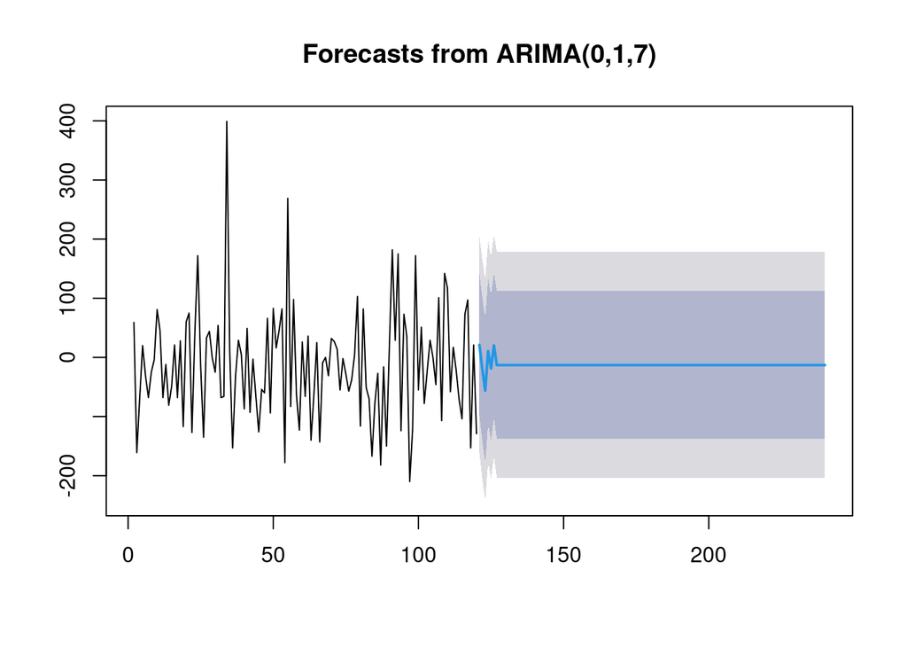

```r
data.ramalan <- ramalan$mean
plot(ramalan)
```

Berdasarkan hasil plot ramalan di atas, dapat dilihat bahwa ramalan ARIMA(0,1,7) cenderung stabil hingga akhir periode. Selanjutnya, dapat dicari nilai akurasi antara hasil ramalan dengan data uji sebagai berikut.

## Akurasi Model

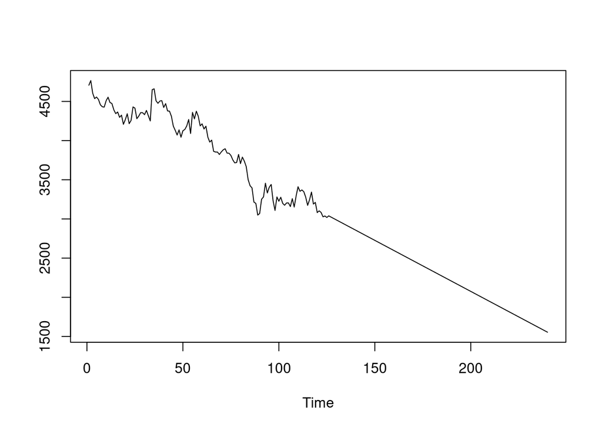

```r
pt_1 <- train[120] #nilai akhir data latih
hasil.forc.Diff <- data.ramalan
hasil <- diffinv(hasil.forc.Diff, differences = 1) + pt_1
#has.1 sama hasilnta dengan: cumsum(c(pt_1,hasil.forc.Diff))
ts.plot(train,hasil)
```

```r
perbandingan.da<-matrix(data=c(head(test, n=30), hasil[-1]),
                     nrow = 30, ncol = 2)
colnames(perbandingan.da)<-c("Aktual","Hasil Forecast")
perbandingan.da
```

```
##       Aktual Hasil Forecast
##  [1,]   3083       3103.154
##  [2,]   3029       3083.353
##  [3,]   2999       3027.182
##  [4,]   3051       3037.774
##  [5,]   2996       3019.099
##  [6,]   3026       3039.337
##  [7,]   3011       3026.311
##  [8,]   3006       3013.284
##  [9,]   3053       3000.257
## [10,]   3078       2987.231
## [11,]   3062       2974.204
## [12,]   3087       2961.178
## [13,]   2996       2948.151
## [14,]   3002       2935.124
```

[output cut: 16 more lines]

```r
accuracy(ts(hasil[-1]), head(test, n=30))
```

```
##                ME     RMSE     MAE       MPE     MAPE
## Test set 9.566333 48.29035 38.7983 0.2885626 1.322828
```